# Milestone Report 1: Exploratory Analysis

Ryan Till

December 7, 2018

# Summary

In this project we will be designing a model that predicts the next word to come in sentence. For this Milestone Report, we will only be doing some minor exploratory analysis. The data I’ll be using for my project can be downloaded [here](https://d396qusza40orc.cloudfront.net/dsscapstone/dataset/Coursera-SwiftKey.zip). The specific files I will be looking at are ‘en_US.blogs.txt’, ‘en_US.news.txt’ and ‘en_US.twitter.txt’ (in the en_US subdirectory). The packages I used to read and analyze the data are ‘NLP’ and ‘reader’.

# Summary Statistics

Below are some summary statistics about the line, character and word counts for each file.

**Number of Lines**

| File | Line Count |
| --- | --- |
| en_US.blogs.txt | 899288 |
| en_US.news.txt | 1010242 |
| en_US.twitter.txt | 2360148 |

**Character Count Summary**

```
##                   Min. 1st Qu. Median Mean     3rd Qu. Max.  SD
## en_US.blogs.txt   1    47      156    229.987  329     40833 258.6608
## en_US.news.txt    1    110     185    201.1628 268     11384 133.2171
## en_US.twitter.txt 2    37      64     68.68045 100     140   37.22725
```

**Word Count Summary**

```
##                   Min. 1st Qu. Median Mean     3rd Qu. Max. SD
## en_US.blogs.txt   1    9       28     41.51521 59      6630 46.27128
## en_US.news.txt    1    19      31     34.02406 45      1792 22.59043
## en_US.twitter.txt 1    7       12     12.86934 18      47   6.903736
```

We can see that in ‘en_US.blogs.txt’ and ‘en_US.news.txt’ there are some fairly large outliers. This is evident due to the large difference between the max and 3rd quartile values in their summary for both character and word count.

# Data Visualizations

Here we will attempt to visualize the distribution of both character and word count in each file. Note that the previously mentioned outliers in ‘en_US.blogs.txt’ and ‘en_US.news.txt’ are exclued from these histograms so we can get a cleaner view of the distribution. More specifcally, the x-axis only goes up to 5 times the standard deviation of the corresponding data.

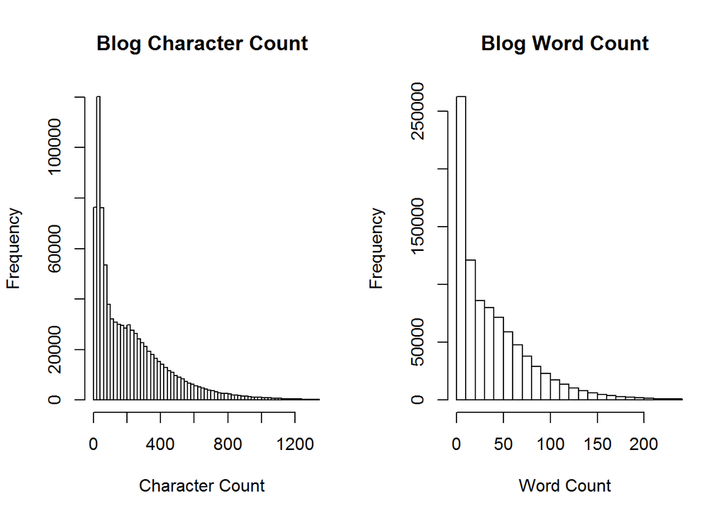

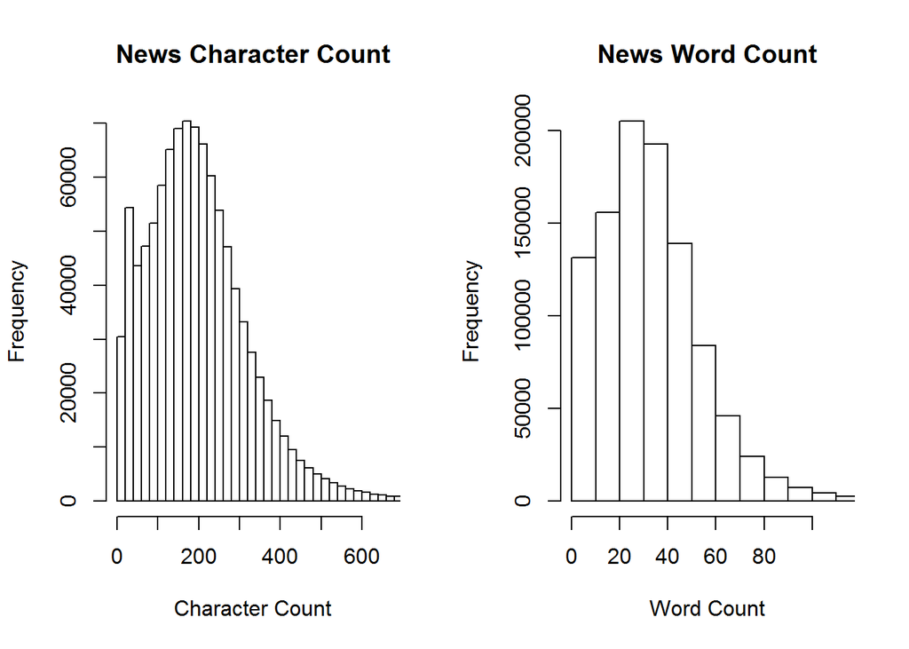

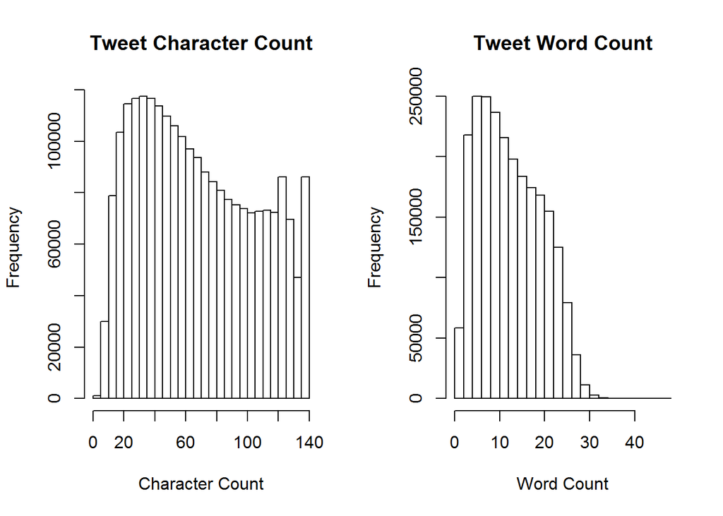

# Conclusion

Now that I’m able to read and work with the data, the next steps are to filter out any profanity and begin developing a prediction algorithm. My initial approach to building the algorithm will be to start gathering data on various ngrams throughout the text, focusing first on 2-word combinations, then moving to 3 and perhaps 4 if my resources allow it. The challenges I forsee with this will be the sheer size of the datasets being used.